# 0014_treatment_networks

Dan MacLean

2018-08-28

## What are the networks like?

The premise of extracting TF-target edges and compiling a network, as prepared for in the previous analysis, is not such a good one. I can’t compile a full network, because for each TF-target pair predicted as interacting we only have one activation peak (the biggest one), so the full range of treatments a TF-target is present in isn’t represented. The network could only show a TFs strongest interactions.

It may be possible to infer the other treatments, with a better extraction function. But it would be hard to calibrate it.

Building and analysing the network structure is probably a bit out of scope, then. With this analysis.

```r
net_data <- readr::read_csv("../data/treatments_and_significant_pairs.csv") %>%
  dplyr::select(TF_affy, Target_affy, TF_AGI, Target_AGI, treatment, tissue, time) %>%
  dplyr::mutate(edge_tag = paste0(TF_affy, "-", Target_affy))
summarized <- net_data %>%
  group_by(treatment, tissue) %>%
  summarize(edges = n_distinct(edge_tag),
            targets = n_distinct(Target_affy),
            tfs = n_distinct(TF_affy),
            tf_ids = list(treatment = unique(TF_affy) )
            )
names(summarized$tf_ids) <- paste0(summarized$treatment, "_", summarized$tissue)
```

## How are TFs shared by the different treatments?

Of the treatments that could be extracted, which TFs crop up in multiple, or interesting sets

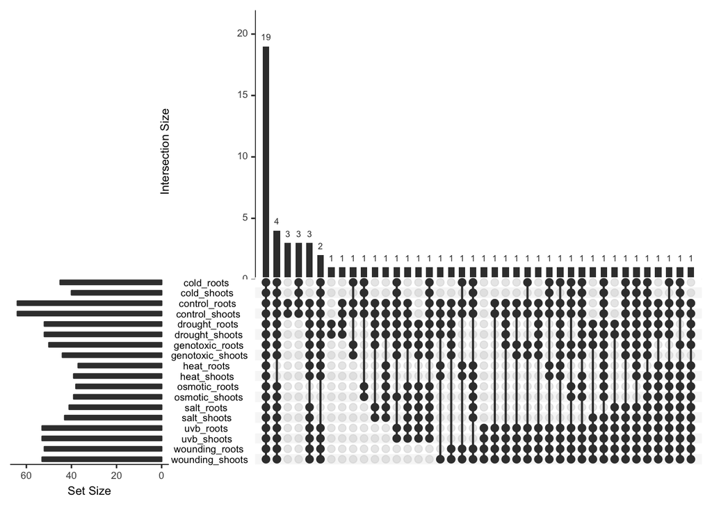

```r
library(UpSetR)
upset(
  fromList(summarized$tf_ids),
  sets = sort(names(summarized$tf_ids), decreasing = TRUE),
  keep.order = TRUE,
  order.by = "freq",
  mb.ratio = c(0.55, 0.45)
  )
```

This figure shows the treatment/tissue combinations and the overlap of found TFs.

There are 19 in all treatments; 4 in everything but heat; 3 in everything not osmotic, not cold; 2 not salt not osmotic.

Interesting to see what they are. How they’re related.